# Machine Learning Project

Alexis Gortaire

5 de marzo de 2017

# Executive Summary

The goal of this exercise is to use the reading from several sensory data from accelerometers on the belt, forearm, arm, and dumbell of 6 participants, and to predict the outcome of the manner in which they did the exercise. This outcome is denoted by classe variable in the dataset. These participants were further asked to perform barbell lifts correctly and incorrectly in 5 different ways. More information is available from the website here: http://groupware.les.inf.puc-rio.br/har (see the section on the Weight Lifting Exercise Dataset). We have surveyed different machine learning techniques and concluded that Random Forest was the best model for predicting the manner in which the participants did the exercise.

# Data loading

We have tow data sets called: training and testing

```r
#Training Data
DataTrain=read.csv("pml-training.csv",sep = ",")
#Testing Data
DataTest=read.csv("pml-testing.csv",sep = ",")
nombres=DataTest$user_name
```

# Cleaning and Preprocessing Data

```r
#formats
DataTrain[,7:159] = sapply(DataTrain[,7:159],as.numeric)
DataTest[,7:159] = sapply(DataTest[,7:159], as.numeric)
#select variables
DataTrain = DataTrain[,8:dim(DataTrain)[2]]
DataTest = DataTest[,8:dim(DataTest)[2]]

#Imputing missing values
NAS=sapply(DataTrain[,1:dim(DataTrain)[2]],function(x)table(is.na(x)))
NAS=as.data.frame(do.call(rbind,NAS))
NAS=subset(NAS,NAS$'TRUE'!=dim(DataTrain)[1])
NAS=row.names(NAS)

Imput=preProcess(DataTrain[,-dim(DataTrain)[2]],method ="knnImpute")
ImputTrain=predict(Imput,DataTrain[,-dim(DataTrain)[2]])
ImputTest=predict(Imput,DataTest[,-dim(DataTest)[2]])

DataTrain=DataTrain[,!names(DataTrain)%in%NAS]
DataTest=DataTest[,!names(DataTest)%in%NAS]
DataTrain=cbind(DataTrain,ImputTrain[,NAS])
DataTest=cbind(DataTest,ImputTest[,NAS])

# Zero Variability
ZV=nearZeroVar(DataTrain[,-dim(DataTrain)[2]])
DataTrain=DataTrain[,-ZV]
DataTest=DataTest[,-ZV]
```

# Select new training and testing data

```r
set.seed(pi)
indexTrain=createDataPartition(DataTrain$classe,p=0.6,list = F)
NewTrain=DataTrain[indexTrain,]
NewTest=DataTrain[-indexTrain,]
```

# Construction and selecction model

## Tree classification model

```r
library(rattle)
TreeMod=train(classe ~ .,data=NewTrain, method="rpart")
```

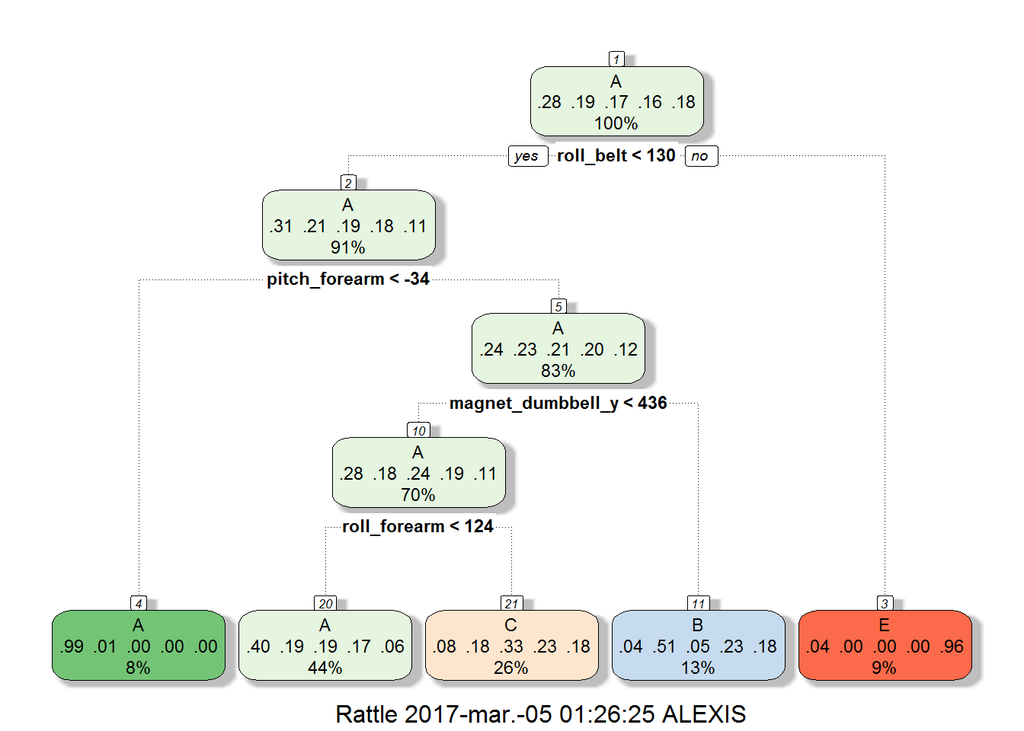

```r
fancyRpartPlot(TreeMod$finalModel)
```

```r
TreePred=confusionMatrix(predict(TreeMod,NewTest),NewTest$classe)
TreePred$overall[1]
```

```
## Accuracy
## 0.501402
```

## Random Forest model

```r
RandMod=train(classe ~ .,data=NewTrain, method="rf",trControl=trainControl(method = "cv",number = 3))
```

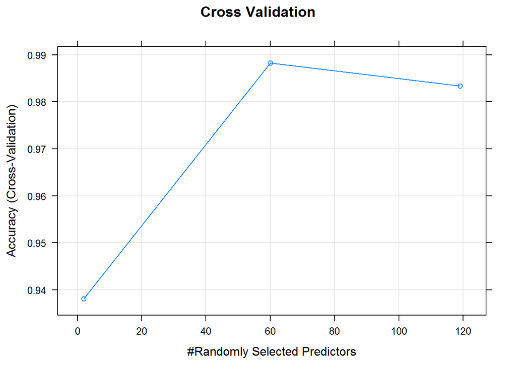

```r
RFPred=confusionMatrix(predict(RandMod,NewTest),NewTest$classe)

plot(RandMod,main="Cross Validation")
```

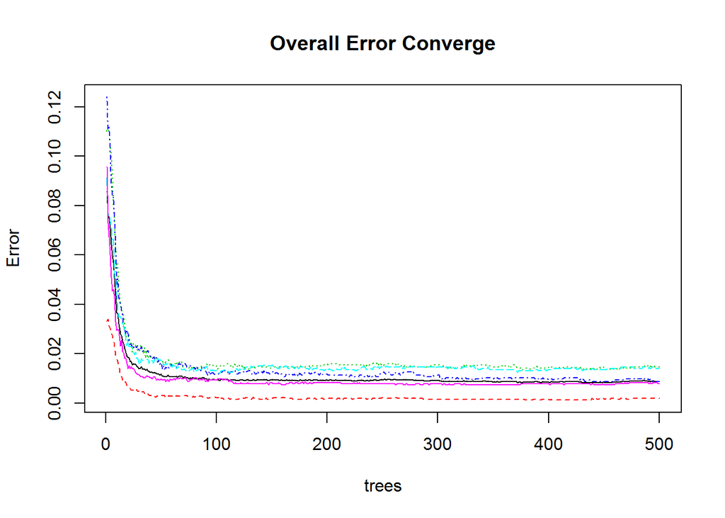

```r
plot(RandMod$finalModel,main = "Overall Error Converge")
```

```r
#Importance
varImp(RandMod)
```

```
## rf variable importance
##
##   only 20 most important variables shown (out of 119)
##
##                      Overall
## roll_belt             100.00
## pitch_forearm          62.44
## yaw_belt               58.31
## magnet_dumbbell_z      48.81
## pitch_belt             46.81
## magnet_dumbbell_y      44.14
## roll_forearm           41.41
## accel_dumbbell_y       25.05
## accel_forearm_x        19.27
## roll_dumbbell          18.98
## magnet_dumbbell_x      18.93
## magnet_belt_z          16.76
## accel_dumbbell_z       16.05
## accel_belt_z           15.33
## total_accel_dumbbell   14.55
## magnet_belt_y          14.20
## magnet_forearm_z       13.61
## gyros_belt_z           11.98
## yaw_arm                11.56
## magnet_belt_x          11.35
```

## Bagging Model

```r
BAGMod=train(classe ~ .,data=NewTrain, method="treebag",trControl=trainControl(method = "cv",number = 3))
BagPred=confusionMatrix(predict(BAGMod,NewTest),NewTest$classe)
#Importance
varImp(BAGMod)
```

```
## treebag variable importance
##
##   only 20 most important variables shown (out of 119)
##
##                   Overall
## roll_belt          100.00
## yaw_belt            81.09
## pitch_belt          71.38
## pitch_forearm       69.55
## magnet_dumbbell_y   63.92
## magnet_dumbbell_z   61.24
## roll_forearm        55.56
## accel_dumbbell_y    50.43
## roll_dumbbell       40.56
## accel_belt_z        37.95
## magnet_belt_y       36.56
## magnet_belt_z       32.26
## magnet_dumbbell_x   30.94
## accel_dumbbell_z    26.67
## accel_forearm_x     26.05
## gyros_belt_z        23.34
## yaw_arm             23.04
## total_accel_belt    22.46
## magnet_belt_x       21.67
## accel_arm_x         21.21
```

## Summary Accuaracy

```r
Accuaracy <- data.frame(Tree=TreePred$overall[1],
                    rf=RFPred$overall[1],
                    bagging=BagPred$overall[1])
Accuaracy
```

```
##              Tree        rf  bagging
## Accuracy 0.501402 0.9908233 0.982284
```

## Cross Validation

The cross validation graph shows that the model with 60 predictors is selected by the best accuracy. ##Overall error That graph tell us that the overall error converge at around 100 trees. So it is possible to speed up our algorithm by tuning the number of trees. ##Selection How I show in Accuaracy object the best model is random forest with accuaracy of 0.99.

# Prediction with model selected

In this section, we use random forest model we built in last section to predict the test data and predict the class of exercise that the users did.

```r
DataTest$class=as.character(predict(RandMod,DataTest))
table(DataTest$class,nombres)
```

```
##    nombres
##     adelmo carlitos charles eurico jeremy pedro
##   A      1        1       1      1      2     1
##   B      0        2       0      2      2     2
##   C      0        0       0      0      1     0
##   D      0        0       0      0      1     0
##   E      0        0       0      1      2     0
```

# Conclusion

We conclude that both the preprocess and the random forest is the best prediction model for our dataset. The error estimation obtained by random forest is conclusively lower than that of the other modellers we have surveyed.